# A Deep Dive into Water Contamination

### Peter Schaldenbrand, Husnie Almoubayyed, Zecong Hu, Xinyi Ju

### Carnegie Mellon University

## Executive Summary

- Statistics get a bad reputation due to people's misunderstanding of correlations when too many variables are involved.
- Often times, conditioning on an external variable can give insight when looking at the correlation relationship between two variables.
- We clustered the data to find how the correlations differ inter-cluster and intra-cluster. From this analysis, we can determine which clusters contain instances where there is causation of water contamination.

Correlations are often times misunderstood and misused to misrepresent agendas as truths. A lot of the times, 2 things that are highly correlated, are independent when conditioned on a 3rd variable. For example, smoking and high life expectancy seem very highly correlated at first, which could make an argument for smoking as being the cause for living a long healthy life. The truth, however, is far from it: when conditioned on income, smoking and life expectancy are anti-correlated -- this brings us to the more sensible reasoning that wealthy people have higher life expectancy and therefore more time to smoke, and also more money to buy cigarettes.

In the datasets we were presented with a lot of variables that may be correlated with the level of water contamination, but we wanted to set out on finding the ones that matter and the ones that are irrelevant (where the correlation is explained away when conditioned on a third variable).

We do not know if there exists a variable in this data set that explains a causal relationship between its value and water contamination, but we'd like to lay out an intelligent plan to discover a cause. We clustered counties of the united states based on their similarities in population size, education, and income. We determined that the average contamination in these clusters were very different. From this information we can conclude that the counties that have high average water contamination, contain the causation variable. It is impossible to say whether the variable is contained within this data set, but for further research, one could examine the clusters to see what is actually causing the contamination rather than what only correlates with it.

## Overview of Water Contamination

Let's take a look at the topic before going further into the anlaysis. Water is covering 70% of the Earth's surface and accounting for nearly 60% of an adult's body weight. While human life is highly dependent on drinkable water, the condition of water pollution is critical.

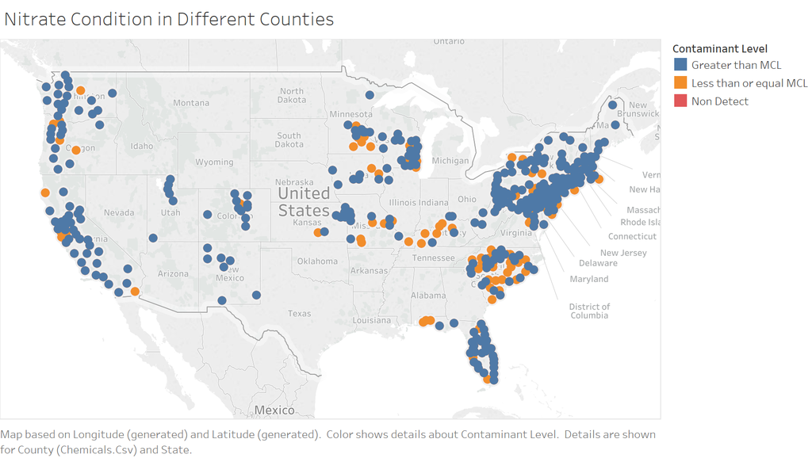

```python
from IPython.display import Image
from IPython.core.display import HTML
Image('/Users/myhome/Downloads/Condition.png')
```

## Data Preprocessing

The data that we're interested in is stored in separate tables under different formats, each with a number of missing values, so cleaning and merging is important. We now describe the preprocessing methods we apply on each table, and explain why they're necessary.

We reiterate our goal: we need one row of data per county, each containing the following values at a specific year:

- contaminant measurement;
- median earnings;
- population;
- percentage of population with bachelor's degree or higher.

#### The `chemicals` Table

The `chemicals` table is probably the most toughest to deal with, mainly due to the following reasons:

- There are 6 types of contaminants recorded, but each type uses a different unit of measurement. Some units aren't comparable so it's difficult to build an aggregate out of them. But on the other hand, using all measurements greatly complicates the problem.
- For each type of chemical, measurements are recorded per community water system (CWS), and there can be multiple CWS's in a county, each serving different populations. We also need to build an aggregate for each county.
- There are missing values in CWS measurements. For instance, Burlington Waterworks is one of the larger CWS's in Racine, Wisconsin, and it has recorded nitrate measurements in 2001 and 2003, but not in 2002. We need to fill in the missing data, otherwise the aggregates we build would be biased.

To deal with these problems, we perform the following preprocessing steps:

- We only consider nitrate among all contaminants, since it has the most measurements in the dataset. Our choice is based on the empirical evidence that correlation analysis is more accurate with more data.
- We fill in missing values by linearly interpolating measurements over time for each CWS. Specifically, if we have measurements $y_1$and $y_2$ on years $x_1$ and $x_2$, then the interpolated measurement for year $x\ (x_1<x<x_2)$ would be $y_1+(x-x_1)(y_2-y_1)/(x_2-x_1)$. We choose linear interpolation due to its simplicity.
- We also perform linear interpolation for serving population, and use their sum as the population for the county. This makes more sense than using the entire population because the list of CWSs in the data is probably not an exhaustive list.
- We build the aggregate for each county by averaging nitrate measurements for each CWS weighted by the population they serve. The reason for using weighted average is because we observe great differences in serving population in the data, with smaller ones only serving dozens and greater ones serving hundreds of thousands. Simply averaging would bias the aggregate.

After these steps, we obtain aggregated nitrate measurements and population for each county in each year.

#### The `education_attainment` Table

The main problem of the `education_attainment` table is :

- The time span of the educational attainment is a little different from the other tables. While we get yearly data from others, the educational attainment data is actually based on a time point rather than a time period. We also found that the most recent data of 2012-2016 is actually a 5-year estimate based on a survey conducted in 2016.

To deal with this problem, the process we took is :

- We decide to use the cross-sectional data rather than the panel data. The reason is that the time span of the educational attainment is static, it is not reasonable to take it as constant for the whole time period. Therefore, we use a static time point for the other dependent variables, which can also deal with missing values.

#### The `earnings` Table

The `earnings` table consists of the information on median earnings of 26 specific industries from 2010 to 2016. The main problems in this table mainly lies in the following fields:

- The industry is very specific and there are some overlap in industries. For example, there are median salary of education services, health social industries and the total group of education services and health social.
- The time span of the industry-specific median earnings are not perfectly matched with the ones in the `industry_occupation` table.
- There are missing values in specific year of specific county and industry.

To deal with these problems, we perform the following preprocessing steps:

- We generize the industry in order to match up with the industry of the `industry_occupation` table.
- As for the missing value, we choose to use the average median earning among 2012-2016 of each industry as a substitute for the median average among years. The reason is that the median earning is not going to change a lot among 6 years.

#### The `industry_occupation` Table

For the `industry_occupation`table, we simply take the average working population from 2010-2016 as the attribute for working population, for we chose a static time point for the dependent variable.

After the pre-processing procedure, the Nitrate levels for the data used is plotted below:

```python
py.iplot(figNitrateMap)
```

```
The draw time for this plot will be slow for clients without much RAM.
```

[interactive chart not shown]

## Clustering

Before performing correlation analysis on the entire dataset, we first performed clustering analysis. This is useful because correlation analysis tests for linear relationships, but it might not always be the case for real data. First clustering the data and then performing correlation analysis on each cluster would allow a piecewise linear relationship.

We used the K-means algorithm for clustering. K-means is an iterative algorithm that assigns each data point to one of $K$ clusters, where $K$ is a predefined parameter. In practice, we tried different values of $K$ and qualitatively evaluated. We plotted the data points in 3D space and colored them according to its assigned cluster. An ideal cluster assignment should:

- have a comparable number of data points in each cluster. If any cluster contains too few data points then maybe we have too many clusters.
- have high correlation for data points in each cluster compared to performing correlation analysis for the whole dataset. If data points in some cluster has low correlation then we probably have too few clusters.

We clustered the counties based on population size, median income, and their education level. An important piece of information to remember is that we did not cluster using the Nitrate contamination variable. We left this out to determine if it varied amongst the calculated clusters. Here is the results of the mean of the contamination versus the cluster.

| Cluster Number | Number of Counties In Cluster | Average Nitrate Contamination |
| --- | --- | --- |
| 0 | 1156 | 0.98343 |
| 1 | 3 | 0.68273 |
| 2 | 51 | 0.79969 |
| 3 | 116 | 0.91362 |
| 4 | 13 | 1.23075 |

```python
py.iplot(fig3D)
```

[interactive chart not shown]

Since each data point corresponds to a county, this is what it looks like when the map is colored according to assigned clusters:

```python
py.iplot(figClusters)
```

```
The draw time for this plot will be slow for clients without much RAM.
```

[interactive chart not shown]

## Correlation Analysis

$$ \begin{array}{r|rrrr} & \text{Population} & \text{Nitrate Value} & \text{Pct. College Bachelors or Higher} & \text{Median Income}\\ \hline \text{Population} & 1 & -0.016538 & 0.298349 & 0.275398\\ \text{Nitrate Value} & -0.016538 & 1 & -0.005914 & 0.054052\\ \text{Pct. College Bachelors or Higher} & 0.298349 & -0.005914 & 1 & 0.645021\\ \text{Median Income} & 0.275398 & 0.054052 & 0.645021 & 1 \end{array} $$

We plotted each of the clusters. For every cluster there was a population, education, income and contamination variable. In the plots we fit a line through the data that showed the correlation between population and contamination levels as an example. Each cluster resulted in very diverse line fittings. For instance, the line in cluster two had a positive slope, and the slope in cluster four had a negative slope. Had we treated all the data the same, we would have missed this divergence in correlations.

```python
py.iplot(figCluster2)
```

[interactive chart not shown]

```python
py.iplot(figCluster4)
```

[interactive chart not shown]

Using clusters two and four above as examples, we can see that population was only correlated with contamination. As with our example in the introduction with smoking and life expenctancy, once you condition on this split in the data, we lose the exact correlation between population and contamination. So rather than concluding that population is a predictor of contamination, we suggest looking at a particular few counties within a cluster to determine predictors and causes of contamination.

## Conclusion

The data set given in this competition was not complete enough to have sufficient evidence of causal realtionships between the variables and contamination of water. Meaning, that there could be confounding variables that weren't measured that are actually causing the contamination. So we did not set out to determine the causes of the contamination, but rather to isolate a few counties that contain the cause.